# Open Cohort Microsimiulation Model

Fernando Alarid-Escudero, PhD (1)

Eva A. Enns, MS, PhD (1)

M.G. Myriam Hunink, MD, PhD (2,3)

Hawre J. Jalal, MD, PhD (4)

Eline M. Krijkamp, MSc (2)

Petros Pechlivanoglou, PhD (5)

Alan Yang, MSc (5)

14/06/2019

In collaboration of:

1 University of Minnesota School of Public Health, Minneapolis, MN, USA

2 Erasmus MC, Rotterdam, The Netherlands

3 Harvard T.H. Chan School of Public Health, Boston, USA

4 University of Pittsburgh Graduate School of Public Health, Pittsburgh, PA, USA

5 The Hospital for Sick Children, Toronto and University of Toronto, Toronto ON, Canada

## Introduction

This report is about the implementation of open cohort microsimulation models in R. Most microsimulation models that are being used today are closed cohort, meaning that the total number of individuals in the simulated cohort remains fixed throughout follow-up. Open cohort microsimulation models allow new individuals to enter the cohort at any time cycle. This report contains an example to illustrate both the implementation and the flexibility of open cohort simulation models.

## 01 Install and Load packages

```r
rm(list = ls())  # Delete everything that is in R's memory
if (!require(plyr))       install.packages('plyr')       ; library(plyr)
if (!require(reshape2))   install.packages('reshape2')   ; library(reshape2)
if (!require(data.table)) install.packages('data.table') ; library(data.table)
if (!require(diagram))    install.packages('diagram')    ; library(diagram)
```

## 02 Load functions

The script of the file includes detailed documentation of the functions that we wil use.

```r
source('Functions.R')
```

## 03 Input Model Parameters

There are three states in the model and they are ‘healthy’, ‘pregnant’ and ‘dead’, denoted as ‘H’, ‘P’ and ‘D’, respectively. The simulated cohort consists of 10,000 men and women from ages 14 to 44. The follow-up period is 40 years (480 monthly cycles).

Ages are sampled from a distribution of age in the file `agedist.csv`. The distribution of sex is 51% female. Age- and sex-dependent mortalities are taken from `mort.csv`.

To allow pregnant women to enter the cohort at the beginning , we start 9 montly cycles earlier.

```r
set.seed(1987)                            # set the seed

# Model structure
v.n <- c("H", "P", "D")                   # vector with state names
n.s <- length(v.n)                        # number of states
c.l <- 1/12                               # cycle length
max.fu <- 40                              # follow-up years
n.t <- max.fu / c.l                       # number of cycles
n.i <- 10000                              # number of individuals
d.r <- 1.5                                # annual discount rate
v.M_Init <- rep("H", times = n.i)         # initial state for all individual at the start of the model

# Start 9 cycles earlier
n.t <- n.t + 9

# Specify gender distribution
p.female <- 0.51

# Load age distribution in the population
v.ageDist   <- read.csv("agedist.csv")
# Only sample 14 to 44 year olds
v.ageDist   <- v.ageDist[v.ageDist$Age >= 14 & v.ageDist$Age <= 44,]

# Generate baseline characteristics
v.ages      <- as.numeric(v.ageDist$Age)

v.ageFemale <- sample(x = v.ages, replace = T, size = n.i * p.female,
                      prob = c(v.ageDist[1,2], diff(v.ageDist[,2])))

v.ageMale   <- sample(x = v.ages, replace = T, size = n.i * (1 - p.female),
                      prob = c(v.ageDist[1,3], diff(v.ageDist[,3])))

df.X        = data.frame(ID = 1:n.i, Age = c(v.ageFemale, v.ageMale),
                         Sex = c(rep('Female',length(v.ageFemale)), rep('Male',length(v.ageMale))),
                         MotherID = rep(NA, n.i))
df.X$Sex    <- as.character(df.X$Sex)
df.X        <- df.X[sample(nrow(df.X)), ]
df.X$ID     <- rownames(df.X) <- 1:n.i

# load and format age- and sex- dependent mortatlities
p.mort      <- read.csv('mort.csv')
p.mort_m    <- subset(p.mort, select = c(Age, Male))
p.mort_m1   <- melt(p.mort_m, id='Age')
p.mort_m1   <- p.mort_m1[rep(seq_len(nrow(p.mort_m1)), each=5), ]
p.mort_m1   <- p.mort_m1[-c(1:4,6,107:110),]
p.mort_m1$Age <- 0:100
p.mort_f    <- subset(p.mort, select = c(Age, Female))
p.mort_f1   <- melt(p.mort_f, id = 'Age')
p.mort_f1   <- p.mort_f1[rep(seq_len(nrow(p.mort_f1)), each=5), ]
p.mort_f1   <- p.mort_f1[-c(1:4,6,107:110),]
p.mort_f1$Age <- 0:100
p.mort1     <- rbind(p.mort_m1, p.mort_f1)
colnames(p.mort1) <- colnames(p.mort_f1) <- colnames(p.mort_m1) <- c('Age', 'Sex', 'p.HD')

# Transition probabilities
p.HP <- 0.0014         # probability healthy -> pregnant
p.PD <- 0.01           # probability pregnant -> death
```

## 04 Probability functions

The diagram below illustrates basic structure of the model.

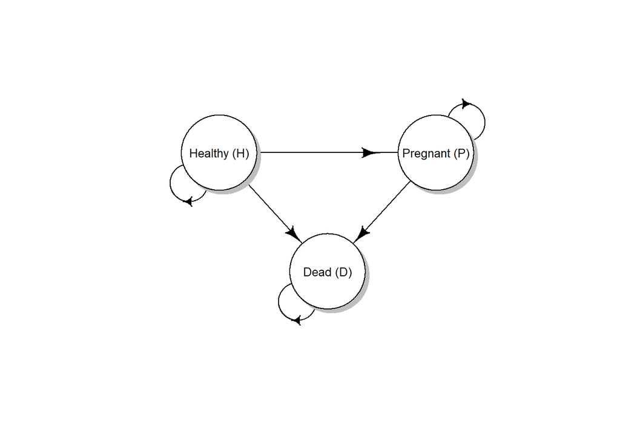

```r
v.n1 <- c("Healthy (H)", "Pregnant (P)", "Dead (D)")
connect <- matrix(0, n.s, n.s, dimnames = list(v.n1, v.n1))
connect["Healthy (H)" ,  "Pregnant (P)"]   <- ""
connect["Healthy (H)" ,  "Dead (D)"]    <- ""
connect["Pregnant (P)",  "Dead (D)"] <- ""
connect["Pregnant (P)",  "Pregnant (P)"] <- ""
connect["Dead (D)"    ,  "Dead (D)"] <- ""
connect["Healthy (H)" ,  "Healthy (H)"] <- ""

diagram::plotmat(t(connect), c(2,1), self.cex = 0.5, curve = 0,
                 self.shiftx = c(-0.08,0.08,-0.08), arr.pos = 0.7,
                 latex=T, arr.type = "curved", relsize = 0.85,
                 cex = 0.8, box.cex = 0.8, lwd = 1)
```

```r
Probs <- function(M_it) {
  # Arguments
  # M_it: current health state
  # Returns
  # m.p.it: matrix of probabilities for all individuals in a given cycle

  m.p.it           <- matrix(0, nrow = n.s, ncol = n.i)  # create matrix of state transition probabilities
  rownames(m.p.it) <-  v.n                               # give the state names to the rows

  # Determine eligibility of getting into pregnant state
  sex_female       <- df.X$Sex == 'Female'
  age_14_44        <- df.X$Age >= 14 & df.X$Age <= 44
  female_14_44     <- sex_female & age_14_44

  sex_male         <- df.X$Sex == 'Male'
  age_not_14_44    <- df.X$Age < 14 | df.X$Age > 44
  cant_preg        <- sex_male | age_not_14_44

  # Look up baseline probability and rate of dying based on individual characteristics
  p.HD_f           <- p.mort_f1[df.X$Age[df.X$Sex=="Female"] + 1,]
  p.HD_m           <- p.mort_m1[df.X$Age[df.X$Sex=="Male"] + 1,]
  p.HD_all         <- rbind(p.HD_f, p.HD_m)
  p.HD_P           <- p.HD_all[M_it == "H" & female_14_44, "p.HD"]
  p.HD_noP         <- p.HD_all[M_it == "H" & cant_preg, "p.HD"]

  # Transition probabilities when healthy
  m.p.it[, M_it == "H" & female_14_44]  <- rbind(1 - p.HP - p.HD_P, p.HP, p.HD_P)
  m.p.it[, M_it == "H" & cant_preg]     <- rbind(1 - p.HP - p.HD_noP, p.HP, p.HD_noP)

  # Transition probabilities when pregnant
  m.p.it[, M_it == "P" & df.X$tp <= 9]  <- c(0, 1 - p.PD, p.PD)
  m.p.it[, M_it == "P" & df.X$tp > 9]   <- c(1 - p.PD, 0, p.PD)

  # Transition probabilities when dead
  m.p.it[, M_it == "D"]  <- c(0, 0, 1)

  return(t(m.p.it)) # return transition probability
}
```

## 05 Model process

The model outputs a matrix with inidviduals as rows and cycles as columns. Each value is the state the individual is in in a particular cycle.

The model took about 40-50 seconds to run.

```r
# Record computation time of the model process
start_time <- Sys.time()

# Initiate the matrices
# m.M: health state for each patient at each cycle
m.M  <-  matrix(nrow = n.i, ncol = n.t + 1,
                dimnames = list(paste("ind", 1:n.i, sep = " "),
                                paste("cycle", 0:n.t, sep = " ")))

m.M[, 1] <- v.M_Init            # initial health state for individual i

df.X$tp <- rep(0, nrow(df.X))   # determine eligibilty of giving birth (track time in pregancy)
n.i_hist <- c(n.i)              # store total number of individuals at each cycle
n.i_babies <- c(0)              # store number of newborn babies at each cycle

# Loop through the time cycles
for (t in 1:n.t) {

    # Update time in pregnancy after each cycle
    df.X$tp[m.M[, t] == 'P'] <- df.X$tp[m.M[, t] == 'P'] + 1

    # Get transition probabilities based on health state at t
    v.p <- Probs(m.M[,t])

    # Sample the next health state based on transition probabilities v.p
    m.M[, t + 1]  <- samplev(v.p, 1)

    # Add newborn babies to baseline charasteristics dataframe
    baby.momIDs <- df.X$ID[m.M[, t] == "P" & df.X$tp > 9]
    if (length(baby.momIDs) > 0) {
    baby.IDs   <- c(nrow(df.X)+1):c(nrow(df.X)+length(baby.momIDs))
    baby.Ages  <- rep(0, length(baby.momIDs))
    baby.Sex   <- sample(c(1,2), prob=c(0.5,0.5), replace=T, size=length(baby.momIDs))
    baby.tp    <- rep(0, length(baby.momIDs))
    babies     <- as.data.frame(cbind(baby.IDs, baby.Ages, baby.Sex, baby.momIDs,baby.tp))
    babies$baby.Sex[babies$baby.Sex==1] <- 'Female'
    babies$baby.Sex[babies$baby.Sex==2] <- 'Male'
    colnames(babies) <- colnames(df.X)
    df.X <- rbindlist(list(df.X, babies))

    # Add newborn babies to the health state matrix
    n.babies   <- length(baby.momIDs)
    n.i_babies <- c(n.i_babies, n.babies)
    new_babies_m.M <- matrix(NA, nrow=n.babies, ncol=n.t+1)
    new_babies_m.M[ , t+1] <- rep('H', n.babies)
    rownames(new_babies_m.M) <- paste('ind ', baby.IDs, sep='')
    m.M <- rbind(m.M, new_babies_m.M)
    }

    n.i <- nrow(df.X)              # update the number of individuals
    n.i_hist <- c(n.i_hist, n.i)
    df.X$tp[df.X$tp > 9] <- 0      # reset time in pregnancy to zero after giving birth

    if (t %% c(1/c.l) == 0) {df.X$Age <- df.X$Age + 1}  # increase age by 1 every 12 months

    # Display simulation progress (optional)
    # if(abs(t/(n.t/10) - round(t/(n.t/10), 0)) < 0.02) { # display progress every 10%
    #    cat('\r', paste(round(t/n.t * 100, 0) , "% done", sep = " "))
    # }
}

# Show computation time of the model process
end_time <- Sys.time()
run_time <- end_time - start_time
run_time
```

```
## Time difference of 46.64718 secs
```

## 06 Trace

Here we plot the distribution of the population across health states over time (with the first 9 cycles removed).

By proportion (the number of individuals in each state out of the total number of individuals, in each cycle):

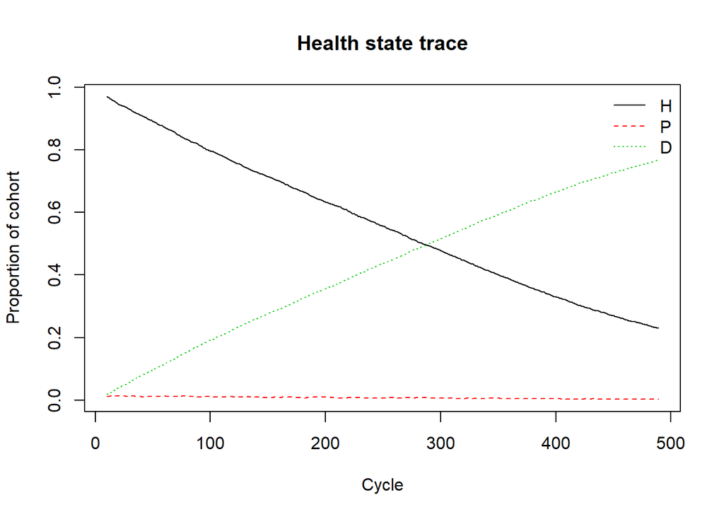

```r
# Remove cycles 0 - 9 (first 9 months)
m.M      <- m.M[, -c(1:10)]
n.i_hist <- n.i_hist[-c(1:10)]

# Calculate the proportion of individuals in each health state at each cycle
m.TR           <- t(apply(m.M, 2, function(x) table(factor(x, levels = v.n, ordered = TRUE))))
m.TR           <- m.TR / n.i_hist
colnames(m.TR) <- v.n
rownames(m.TR) <- paste("Cycle", 10:n.t, sep = " ")

# Plot health state trace
matplot(10:n.t, m.TR, type = 'l',
        ylab = "Proportion of cohort",
        xlab = "Cycle",
        main = "Health state trace")
legend("topright", v.n, col = 1:n.s, lty = 1:n.s, bty = "n")
```

By total number (the number of individuals in each state in each cycle):

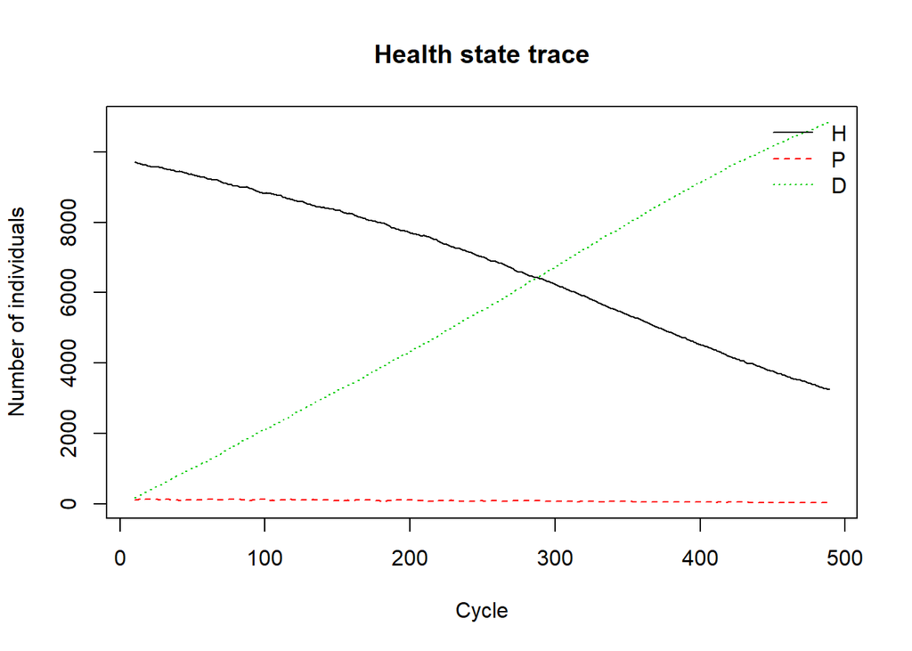

```r
# Count the number of individuals in each health state at each cycle
m.TR_count           <- t(apply(m.M, 2, function(x) table(factor(x, levels = v.n, ordered = TRUE))))
colnames(m.TR_count) <- v.n
rownames(m.TR_count) <- paste("Cycle", 10:n.t, sep = " ")

# Plot health state trace
matplot(10:n.t, m.TR_count, type = 'l',
        ylab = "Number of individuals",
        xlab = "Cycle",
        main = "Health state trace")
legend("topright", v.n, col = 1:n.s, lty = 1:n.s, bty = "n")
```